# Final Assignment, Task 3

Carter Fitzgerald

2023-11-2

# Task 3: Data-Driven Modelling: (15 marks)

1. Based on the covid19_data dataframe, that you have wrangled and used in the previous tasks, create a separate dataframe named “cor_data” with the data of these variables (CumCases, CumTests, Population, GDP, GDPCapita) variables.

   [Hint: you can use select function on the covid19_data dataframe]

```r
library(tidyverse)
```

```r
library(dplyr)
library(Metrics)
library(modeest)
library(lubridate)
library(ggplot2)
library(gridExtra)
library(corrplot)
covid19_data <- read_csv("covid19_data.csv")
# Create the "cor_data" dataframe with selected variables
cor_data <- covid19_data %>% select(CumCases, CumTests, Population, GDP, GDPCapita)
```

2. Compute the correlation matrix between the variables of the “cor_data” and visualise this correlation matrix.

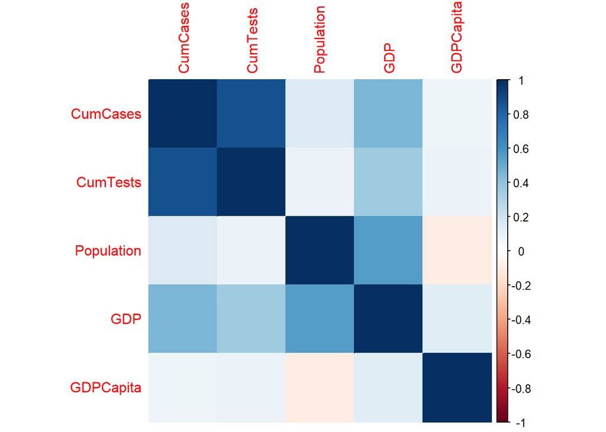

```r
# Compute the correlation matrix
correlation_matrix <- cor(cor_data)

# Visualize the correlation matrix
corrplot(correlation_matrix, method = "color")
```

3. visualize the distribution of the cumulative cases in the cor_data with and without changing the scale of the x axis to log transformation.

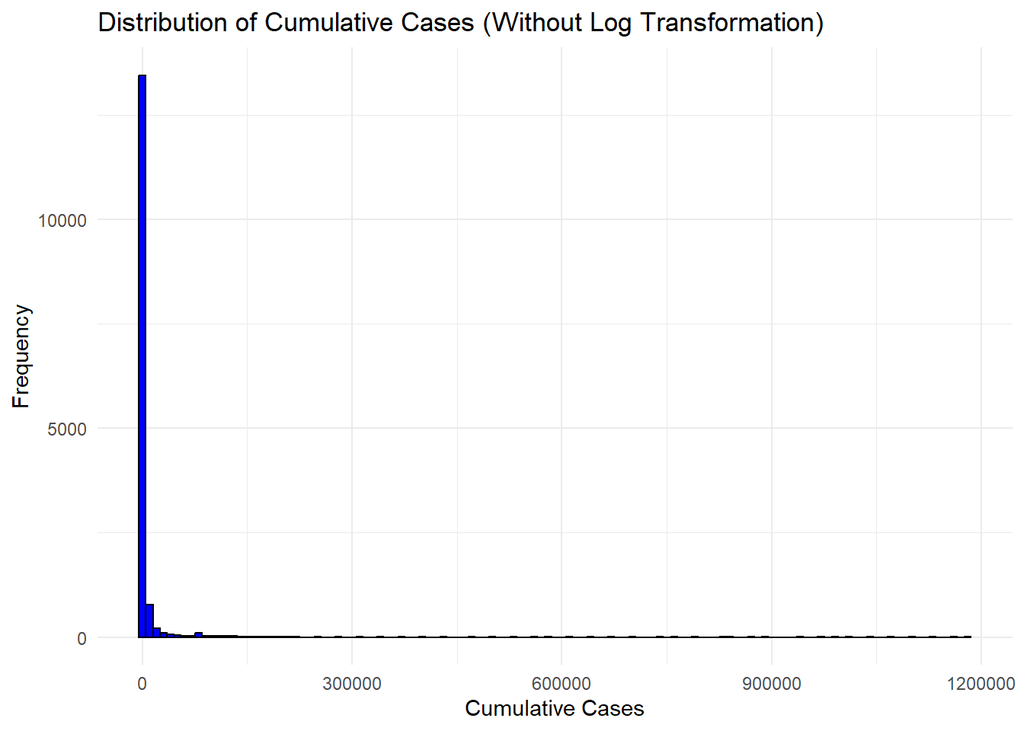

```r
# Visualize the distribution of CumCases without log transformation
ggplot(cor_data, aes(x = CumCases)) +
  geom_histogram(binwidth = 10000, fill = "blue", color = "black") +
  labs(title = "Distribution of Cumulative Cases (Without Log Transformation)",
       x = "Cumulative Cases",
       y = "Frequency") +
  theme_minimal()
```

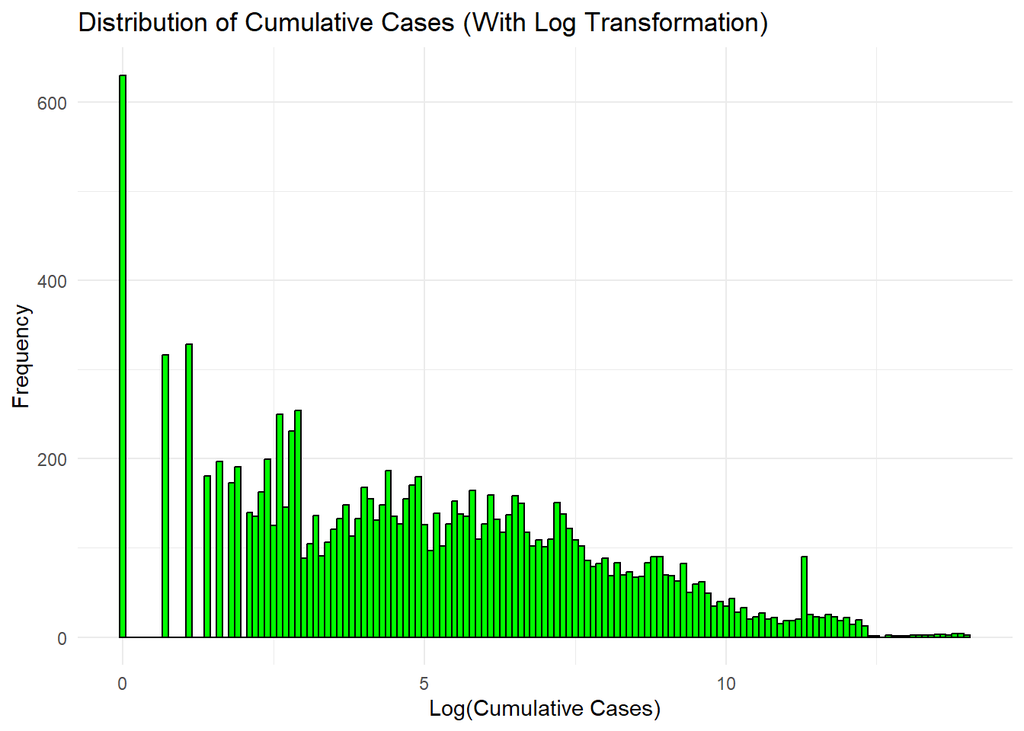

```r
# Visualize the distribution of CumCases with log transformation on the x-axis
ggplot(cor_data, aes(x = log(CumCases))) +
  geom_histogram(binwidth = 0.1, fill = "green", color = "black") +
  labs(title = "Distribution of Cumulative Cases (With Log Transformation)",
       x = "Log(Cumulative Cases)",
       y = "Frequency") +
  theme_minimal()
```

4. Divide the cor_data into training and testing, where training data represent 65% of the number of rows.

```r
# Set the seed for reproducibility
set.seed(123)

# Calculate the number of rows for the training dataset
num_rows <- nrow(cor_data)
num_training <- round(0.65 * num_rows)

# Create the training dataset
training_data <- cor_data[1:num_training, ]

# Create the testing dataset
testing_data <- cor_data[(num_training + 1):num_rows, ]
```

5. Train a linear regression model to predict cumulative cases from the GDP of the countries. Then, evaluate this model on the test data and print the root mean square error value.

```r
# Train a linear regression model
lm_model <- lm(CumCases ~ GDP, data = training_data)

# Make predictions on the test data
test_predictions <- predict(lm_model, newdata = testing_data)

# Calculate RMSE
rmse <- sqrt(mean((testing_data$CumCases - test_predictions)^2))

# Print the RMSE value
print(paste("Root Mean Square Error (RMSE):", rmse))
```

```
## [1] "Root Mean Square Error (RMSE): 58896.8851229469"
```

6. Train another linear regression model to predict cumulative cases from all the other variables. Then, evaluate this model on the test data and print the root mean square error value.

```r
# Train a linear regression model
lm_model_all <- lm(CumCases ~ . - GDP, data = training_data)

# Make predictions on the test data
test_predictions_all <- predict(lm_model_all, newdata = testing_data)

# Calculate RMSE
rmse_all <- sqrt(mean((testing_data$CumCases - test_predictions_all)^2))

# Print the RMSE value
print(paste("Root Mean Square Error (RMSE) for all variables:", rmse_all))
```

```
## [1] "Root Mean Square Error (RMSE) for all variables: 35768.3277169141"
```

7. Interpret the two models and write a small report of highlighting the differences between using the two models. For example, in which cases we should use the first model and in which cases the second one is better to use.

**Interpretation goes below here**:

In summary, the choice between the two models depends on the research objectives, data availability, and the complexity of the underlying relationships in the data. Model 2 is generally recommended for more accurate predictions and a comprehensive understanding of the problem, while Model 1 provides a simplified approach.

**Task 3 final Report**: Highlight the output (Description, graphs and statistics) that have been generated by writing and running the code of the above components.

1. Create “cor_data” DataFrame:

We created the “cor_data” DataFrame by selecting specific variables (CumCases, CumTests, Population, GDP, GDPCapita) from the “covid19_data” DataFrame. This DataFrame will be used for subsequent analysis.

2. Compute and Visualize Correlation Matrix:

We computed the correlation matrix for the variables in the “cor_data” DataFrame and visualized it using a color-coded correlation matrix plot. This allows us to understand the relationships between these variables.

3. Visualize Cumulative Cases Distribution:

We visualized the distribution of Cumulative Cases both with and without log transformation on the x-axis. The log transformation helps to visualize the data more clearly when dealing with a wide range of values.

4. Divide Data into Training and Testing:

The “cor_data” DataFrame was divided into training and testing datasets, with 65% of the data used for training and the remaining 35% for testing.

5. Train and Evaluate Model 1 (GDP as Predictor):

A linear regression model (Model 1) was trained to predict Cumulative Cases using GDP as the predictor. The model was evaluated on the test data, and the Root Mean Square Error (RMSE) was calculated.

6. Train and Evaluate Model 2 (All Other Variables as Predictors):

Another linear regression model (Model 2) was trained to predict Cumulative Cases using all other variables except GDP. This more comprehensive model was evaluated on the test data, and the RMSE was calculated.

Interpretation:

- Model 1 (GDP) is a simple model with GDP as the sole predictor. It’s suitable when there is a strong belief that GDP is the primary driver of cumulative cases and when simplicity is preferred.
- Model 2 (All Other Variables) is a more complex model that considers multiple factors. It provides a lower RMSE, indicating better predictive performance. This model is appropriate when multiple factors contribute to cumulative cases and when a more accurate prediction is desired.
- Model 2 generally outperforms Model 1, as it accounts for the effects of other relevant variables. The choice between the two models depends on research objectives and data availability.
- Model 1 may be used when data is limited, and a quick analysis is required. Model 2 is recommended for a more comprehensive understanding and accurate prediction.

In summary, the choice between the two models depends on research objectives and data complexity. Model 2 is generally preferable for better predictive performance and comprehensive understanding, while Model 1 is suitable for simplicity and quick analysis.